# Protein analysis

AS Huffmyer

2022

This script analyzes and plots data for Symbiotic Integration 2021 protein data.

# **Setup**

Load libraries.

```r
library(dplyr)
library(readr)
library(stringr)
library(gridExtra)
```

```r
library(grid)
library(ggplot2)
library(lattice)
library(Rmisc)
library(ggpubr)
library(lsmeans)
library(tidyverse)
```

# **Load data**

Read in datafiles

```r
data <- read.csv("Mcap2021/Data/Protein/20220407_Protein_data.csv")
Meta <- read.csv("Mcap2021/Data/Protein/20220407_Protein_Meta.csv")
volumes <- read.csv("Mcap2021/Data/Resuspension_volumes.csv")
```

# **Prepare dataframes**

Merging Files and renaming columns

```r
data.1 <- merge(Meta, data, by = c("Well", "Run"))
data.1 <- left_join(data.1, volumes, by=c("Tube.ID"))

# Blank correction for each run separately

Blank <- data.1 %>%
  filter(Sample.Type == "Blank") %>%
  summarise(blk.avg = mean(X562))

data.1$abs.corr <- data.1$X562 - Blank$blk.avg
```

Standard for Run 1

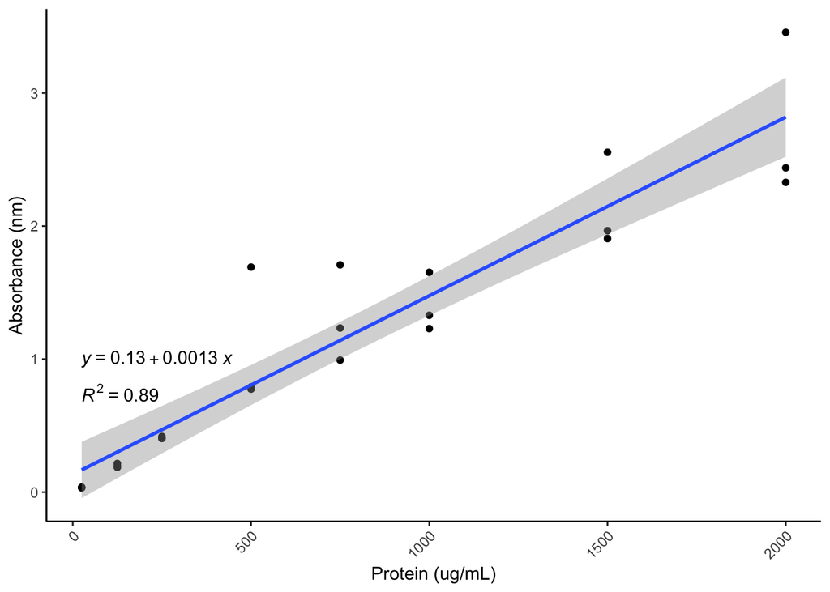

```r
# Standard curve

Standard.1 <- data.1 %>%
  filter(Sample.Type == "Standard")%>%
  filter(Run==1)

Standard.plot.1 <- ggplot(data = Standard.1, aes(x=Concentration, y=abs.corr))+
  ylab("Absorbance (nm)")+ xlab("Protein (ug/mL)") +
  geom_point()+
  geom_smooth(method = "lm") +
  stat_regline_equation(label.y = 1.0, aes(label = ..eq.label..)) +
  stat_regline_equation(label.y = 0.75, aes(label = ..rr.label..)) +
  theme_bw() + theme(panel.border = element_blank(), panel.grid.major = element_blank(),
                     panel.grid.minor = element_blank(), axis.line = element_line(colour = "black")) +
  theme(axis.text.x = element_text(angle = 45, hjust = 1));Standard.plot.1
```

Extract standard curve for Run 1.

```r
lmstandard.1 <- lm (Concentration ~ abs.corr, data = Standard.1)
lmsummary.1 <- summary(lmstandard.1)
```

Standard for Run 2

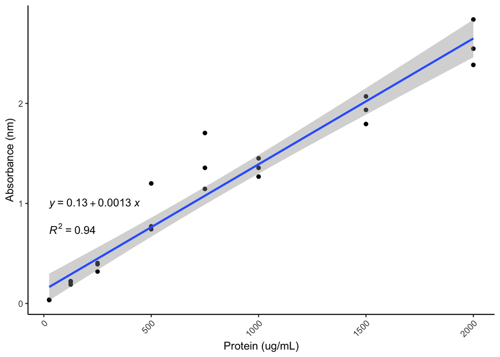

```r
# Standard curve
Standard.2 <- data.1 %>%
  filter(Sample.Type == "Standard")%>%
  filter(Run==2)

Standard.plot.2 <- ggplot(data = Standard.2, aes(x=Concentration, y=abs.corr))+
  ylab("Absorbance (nm)")+ xlab("Protein (ug/mL)") +
  geom_point()+
  geom_smooth(method = "lm") +
  stat_regline_equation(label.y = 1.0, aes(label = ..eq.label..)) +
  stat_regline_equation(label.y = 0.75, aes(label = ..rr.label..)) +
  theme_bw() + theme(panel.border = element_blank(), panel.grid.major = element_blank(),
                     panel.grid.minor = element_blank(), axis.line = element_line(colour = "black")) +
  theme(axis.text.x = element_text(angle = 45, hjust = 1));Standard.plot.2
```

Extract standard curve for Run 2.

```r
lmstandard.2 <- lm (Concentration ~ abs.corr, data = Standard.2)
lmsummary.2 <- summary(lmstandard.2)
```

Standard for Run 3

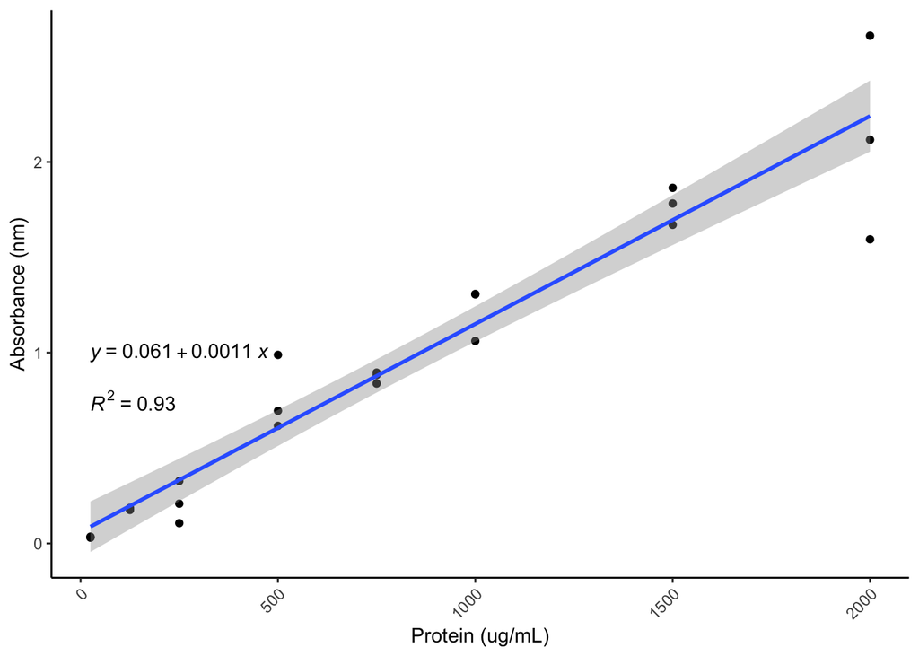

```r
# Standard curve
Standard.3 <- data.1 %>%
  filter(Sample.Type == "Standard")%>%
  filter(Run==3)

Standard.plot.3 <- ggplot(data = Standard.3, aes(x=Concentration, y=abs.corr))+
  ylab("Absorbance (nm)")+ xlab("Protein (ug/mL)") +
  geom_point()+
  geom_smooth(method = "lm") +
  stat_regline_equation(label.y = 1.0, aes(label = ..eq.label..)) +
  stat_regline_equation(label.y = 0.75, aes(label = ..rr.label..)) +
  theme_bw() + theme(panel.border = element_blank(), panel.grid.major = element_blank(),
                     panel.grid.minor = element_blank(), axis.line = element_line(colour = "black")) +
  theme(axis.text.x = element_text(angle = 45, hjust = 1));Standard.plot.3
```

Extract standard curve for Run 3.

```r
lmstandard.3 <- lm (Concentration ~ abs.corr, data = Standard.3)
lmsummary.3 <- summary(lmstandard.3)
```

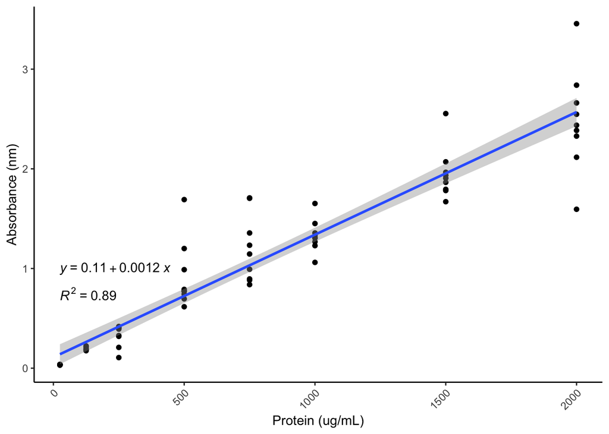

```r
# Standard curve
Standard <- data.1 %>%
  filter(Sample.Type == "Standard")

Standard.plot <- ggplot(data = Standard, aes(x=Concentration, y=abs.corr))+
  ylab("Absorbance (nm)")+ xlab("Protein (ug/mL)") +
  geom_point()+
  geom_smooth(method = "lm") +
  stat_regline_equation(label.y = 1.0, aes(label = ..eq.label..)) +
  stat_regline_equation(label.y = 0.75, aes(label = ..rr.label..)) +
  theme_bw() + theme(panel.border = element_blank(), panel.grid.major = element_blank(),
                     panel.grid.minor = element_blank(), axis.line = element_line(colour = "black")) +
  theme(axis.text.x = element_text(angle = 45, hjust = 1));Standard.plot
```

```r
lmstandard <- lm (Concentration ~ abs.corr, data = Standard)
lmsummary <- summary(lmstandard)
```

For now, use the combined standard and in later code we will run with individual runs.

# **Calculations**

Obtain concentration values for samples from standard curve.

```r
Samples <- data.1 %>% #subsetting Samples
  filter(Sample.Type == "Sample")

Samples$Concentration <- predict(lmstandard, newdata = Samples) #using model to get concentration
```

Normalizing to homogenization volume

Need to account for dilution (here it will be 25/10) - normally 25 but we used 10 Also need to account for resuspension volume (see carbs script)

Concentration (ug/mL) * resuspension (mL) * dilution factor (ratio)= total ug protein -> this will give us ug per tube, we will then normalize ug carbs to ug protein

NOte here that standard is in ug/mL

```r
Samples$Protein.ug <- Samples$Concentration * (Samples$Resuspension_volume / 1000) * (25/Samples$Homo_vol)

#ug/mL concentration * (resuspension uL / 1000) * (25/homogenate volume added)
```

Plot only larvae

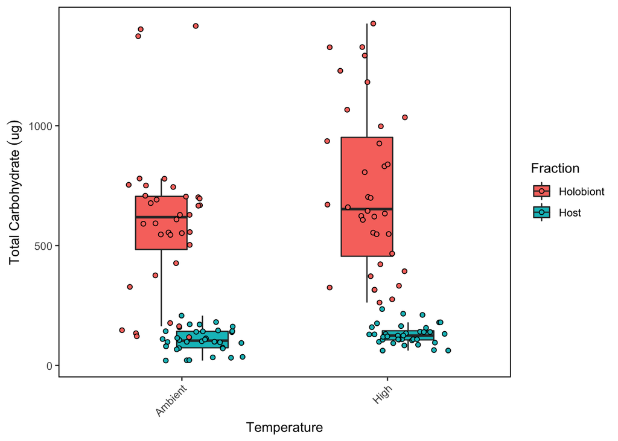

```r
Protein.Plot <- Samples%>%
  filter(!Treatment=="Astrangia")%>%
  ggplot(aes(x=Treatment, y=Protein.ug, fill = Fraction)) +
  geom_boxplot(width=.5, outlier.shape= NA, position = position_dodge(width = 0.4)) +
  geom_point(pch = 21, position=position_jitterdodge(dodge.width=0.4)) +
  xlab("Temperature") + ylab(expression("Total Carbohydrate " (ug))) + #Axis titles
  theme_bw() + theme(panel.border = element_rect(color="black", fill=NA, size=0.75), panel.grid.major = element_blank(),
                     panel.grid.minor = element_blank(), axis.line = element_blank()) +
  theme(axis.text.x = element_text(angle = 45, hjust = 1)); Protein.Plot
```

Test for differences with an anova.

```r
model<-Samples%>%
  filter(!Treatment=="Astrangia")%>%

  aov(Protein.ug~Treatment, data=.)

summary(model)
```

```
##              Df   Sum Sq Mean Sq F value Pr(>F)
## Treatment     1   193052  193052   1.469  0.228
## Residuals   142 18660037  131409
```

# **Calculate Ratio of host:holobiont**

Calculate the ratio of host:holobiont protein

Calculate the average host and average holobiont signal for each sample.

```r
ratios<-Samples%>%
  filter(!Treatment=="Astrangia")%>%
  select(Sample.ID, Treatment, Fraction, Protein.ug)%>%
  group_by(Sample.ID, Fraction, Treatment)%>%
  dplyr::summarise(mean_protein=mean(Protein.ug))%>%
  spread(Fraction, mean_protein)%>%
  mutate(ratio=Host/Holobiont)
```

Plot Host:Holobiont ratios

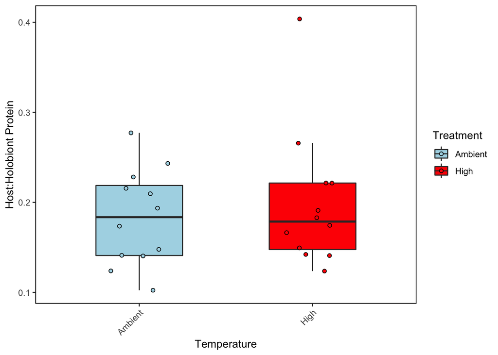

```r
Ratio.Plot <- ratios%>%
  ggplot(aes(x=Treatment, y=ratio, fill=Treatment)) +
  geom_boxplot(width=.5, outlier.shape= NA, position = position_dodge(width = 0.4)) +
  geom_point(pch = 21, position=position_jitterdodge(dodge.width=0.4)) +
  scale_fill_manual(values=c("lightblue", "red1"))+
  xlab("Temperature") + ylab(expression("Host:Holobiont Protein")) + #Axis titles
  theme_bw() + theme(panel.border = element_rect(color="black", fill=NA, size=0.75), panel.grid.major = element_blank(),
                     panel.grid.minor = element_blank(), axis.line = element_blank()) +
  theme(axis.text.x = element_text(angle = 45, hjust = 1)); Ratio.Plot
```

Test for differences with an anova.

```r
model<-aov(ratio~Treatment, data=ratios)
summary(model)
```

```
##             Df  Sum Sq  Mean Sq F value Pr(>F)
## Treatment    1 0.00145 0.001453   0.335  0.569
## Residuals   22 0.09539 0.004336
```

# **Output file to use for protein normalization**

```r
Samples%>%
  filter(!Treatment=="Astrangia")%>%
  select(Tube.ID, Sample.ID, Treatment, Fraction, Protein.ug)%>%
  group_by(Tube.ID, Sample.ID, Treatment, Fraction)%>%
  dplyr::summarise(Protein.ug=mean(Protein.ug))%>%
  write.csv(., "Mcap2021/Output/Protein/protein_output.csv")
```

[output not shown]